# GBSV Minichallenge 1 Notebook 3

Dieses Notbook enthält die Abgaben für die Tage 10 - 15 für die GBSV Minichallenge 1. Der Code sowie die Daten sind in einem GitHub Repository verfügbar und unter diesem Link zu finden: [GitHub Repository](https://github.com/adrianmeier2002/gbsv_minichallenges).

```python
import pandas as pd
import numpy as np
import matplotlib.pyplot as plt
from scipy.signal import fftconvolve
```

## Day 10

### Einführung

Es sollen klassische Filtermethoden auf ein 1D-Zeitreihe-Signal angewendet werden. Hierzu werden erneut die stündlichen Wasserstandsdaten des St.-Lawrence-Stroms verwendet. Ziel ist es, kleine Schwankungen ("Rauschen") zu glätten und langfristige Trends sichtbar zu machen. Zuerst soll mithilfe eines gleitenden Mittelwerts (Moving Average) geglättet werden. So können die Stündlichen Schwankungen oder die Täglichen Schwankungen währen einer Woche geglättet werden.

```python
water_raw = pd.read_csv(
    "data/st_lawrence_water.csv",
    skiprows=8,
    usecols=[0, 1],                # nur die ersten beiden Spalten laden
    names=["Observed_date", "Sealevel"],    # Spaltennamen setzen
    parse_dates=["Observed_date"],      # Datum parsen
    encoding="latin1"
)

water_raw = water_raw.dropna()

print(water_raw.head())
```

```
        Observed_date  Sealevel
0 2015-01-01 00:00:00      0.32
1 2015-01-01 01:00:00      0.32
2 2015-01-01 02:00:00      0.33
3 2015-01-01 03:00:00      0.33
4 2015-01-01 04:00:00      0.33
```

Zuerst wird das signal so gefiltert, das die Täglichen Schwankungen mit einem gleitenden Mittelwert über eine Woche geglättet werden.

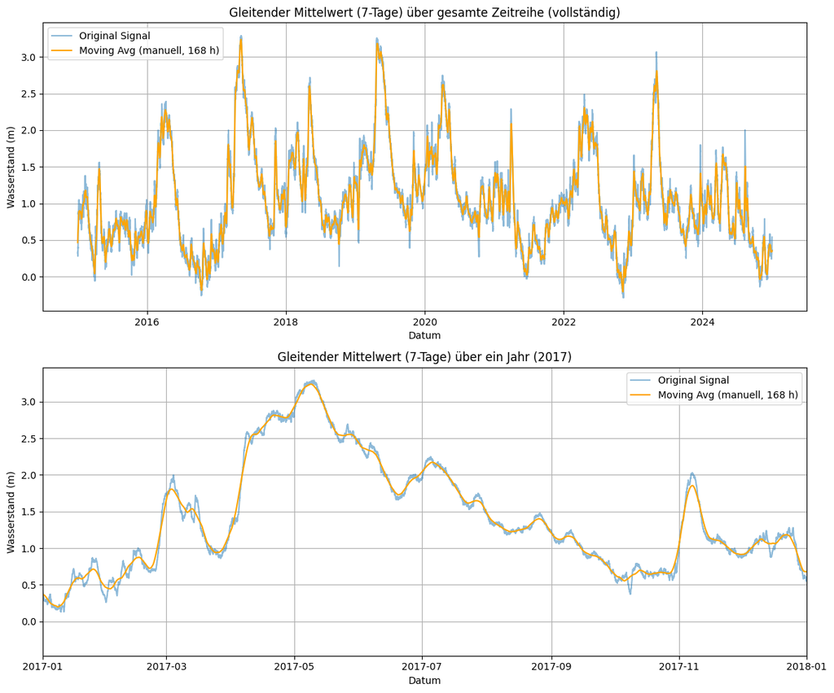

```python
# --- Funktion für manuellen gleitenden Mittelwert (Prefix-Sum-Ansatz) ---
def manual_moving_average(values, window_size):
    """
    Berechnet den gleitenden Mittelwert manuell (ohne NumPy) über die gesamte Zeitreihe.
    Nutzt Prefix-Summen für effiziente Berechnung auch bei grossen Datensätzen.

    Parameter:
        values (list oder np.ndarray): Eingabesignal (z. B. Wasserstandswerte)
        window_size (int): Fenstergrösse in Samples (z. B. 7*24 für 7 Tage bei stündlichen Daten)

    Rückgabe:
        np.ndarray: geglättetes Signal, gleiche Länge wie Eingabe
    """
    x_list = [float(v) for v in values]
    N = len(x_list)
    half = window_size // 2

    # Prefix Sum vorbereiten
    prefix = [0.0] * (N + 1)
    for i in range(N):
        prefix[i + 1] = prefix[i] + x_list[i]

    # Gleitenden Mittelwert berechnen
    x_smooth = [0.0] * N
    for i in range(N):
        start = max(0, i - half)
        end = min(N, i + half + 1)
        length = end - start
        s = prefix[end] - prefix[start]
        x_smooth[i] = s / length

    return np.array(x_smooth)


# --- Signal vorbereiten ---
sig = water_raw.set_index('Observed_date')['Sealevel'].asfreq('h').interpolate(limit=16*24)
x = sig.values
dates = sig.index

# --- Parameter ---
window_size = 7 * 24  # 7 Tage = 168 Stunden

# --- Berechnung mit der Funktion ---
x_manual_centered = manual_moving_average(x, window_size)

# --- Plot: gesamte Zeitreihe + Jahr 2017 ---
plt.figure(figsize=(12,10))

# 1) Gesamtansicht
plt.subplot(2,1,1)
plt.plot(dates, x, label='Original Signal', alpha=0.5)
plt.plot(dates, x_manual_centered, label=f'Moving Avg (manuell, {window_size} h)', color='orange')
plt.title('Gleitender Mittelwert (7-Tage) über gesamte Zeitreihe (vollständig)')
plt.xlabel('Datum')
plt.ylabel('Wasserstand (m)')
plt.legend()
plt.grid()

# 2) Zoom auf Jahr 2017
plt.subplot(2,1,2)
plt.plot(dates, x, label='Original Signal', alpha=0.5)
plt.plot(dates, x_manual_centered, label=f'Moving Avg (manuell, {window_size} h)', color='orange')
plt.xlim([pd.Timestamp("2017-01-01"), pd.Timestamp("2018-01-01")])
plt.title('Gleitender Mittelwert (7-Tage) über ein Jahr (2017)')
plt.xlabel('Datum')
plt.ylabel('Wasserstand (m)')
plt.legend()
plt.grid()

plt.tight_layout()
plt.show()
```

Im oberen Plot sieht man noch relativ wenig, wenn man aber den Zeitraum auf ein Jahr (2017) einschränkt, ist klar, dass die Kurve geglättet wird und die Täglichen Schwankungen verschwinden.

Das Signal kann auch in einem kleineren Fenster gefiltert werden, wenn uns die Täglichen Schwankungen interessieren. Hierzu wird das Signal mit einem gleitenden Mittelwert über 24 Stunden geglättet.

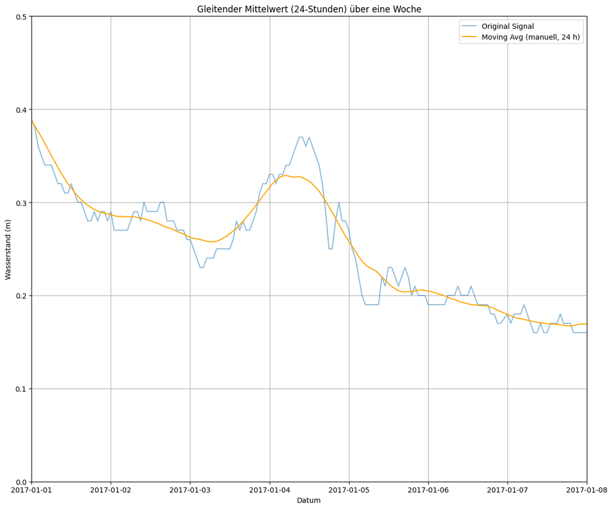

```python
sig = water_raw.set_index('Observed_date')['Sealevel'].asfreq('h').interpolate(limit=16*24)
x = sig.values
dates = sig.index

# --- Parameter ---
window_size = 24  # 24 Stunden

# --- Berechnung mit der Funktion ---
x_manual_centered = manual_moving_average(x, window_size)

# --- Plot: In einer Woche ---
plt.figure(figsize=(12,10))
plt.plot(dates, x, label='Original Signal', alpha=0.5)
plt.plot(dates, x_manual_centered, label=f'Moving Avg (manuell, {window_size} h)', color='orange')
plt.xlim([pd.Timestamp("2017-01-01"), pd.Timestamp("2017-01-08")])
plt.ylim([0, 0.5])
plt.title('Gleitender Mittelwert (24-Stunden) über eine Woche')
plt.xlabel('Datum')
plt.ylabel('Wasserstand (m)')
plt.legend()
plt.grid()

plt.tight_layout()
plt.show()
```

### Vergleich mit Numpy

In Numpy kann der gleitende Mittelwert auch mit der Funktion `np.convolve` berechnet werden. Nachfolgend soll gezeigt werden, ob es eine Differenz zwischen der manuellen Berechnung und der Numpy-Funktion gibt.

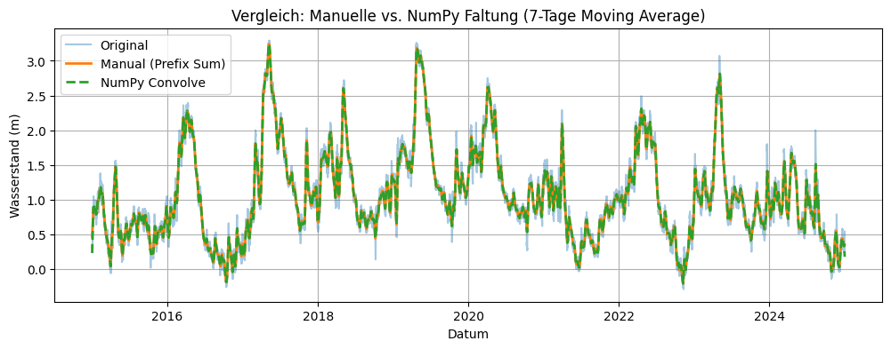

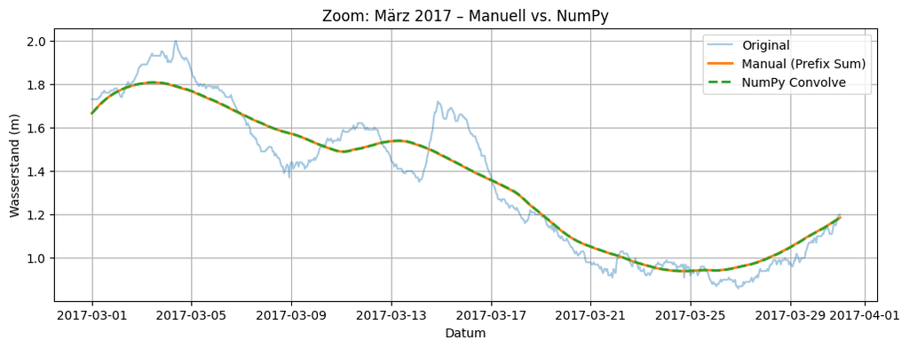

[figure not shown]

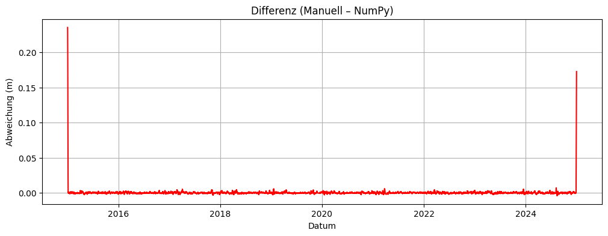

```
RMSE zwischen manuell & NumPy: 0.005864 m
Maximale Abweichung: 0.235579 m
Mittlere Abweichung: 0.000939 m
```

```python
# --- Signal vorbereiten ---
sig = water_raw.set_index('Observed_date')['Sealevel'].asfreq('h').interpolate(limit=16*24)
x = sig.values.astype(float)
dates = sig.index

# --- Parameter ---
window_size = 7 * 24  # 7-Tage-Glättung

# --- 1) Manuelle Berechnung (Funktionsaufruf) ---
x_manual = manual_moving_average(x, window_size)

# --- 2) NumPy Faltung (Referenz) ---
kernel = np.ones(window_size) / window_size
x_numpy = np.convolve(x, kernel, mode='same')

# --- 3) Differenz berechnen ---
diff = x_manual - x_numpy

# --- 4) Plot: gesamtes Signal ---
plt.figure(figsize=(12,4))
plt.plot(dates, x, label='Original', alpha=0.4)
plt.plot(dates, x_manual, label='Manual (Prefix Sum)', linewidth=2)
plt.plot(dates, x_numpy, '--', label='NumPy Convolve', linewidth=2)
plt.title('Vergleich: Manuelle vs. NumPy Faltung (7-Tage Moving Average)')
plt.xlabel('Datum')
plt.ylabel('Wasserstand (m)')
plt.legend()
plt.grid()
plt.show()

# --- 5) Zoom & Vergleich ---
zoom_mask = (dates >= '2017-03-01') & (dates <= '2017-03-31')
plt.figure(figsize=(12,4))
plt.plot(dates[zoom_mask], x[zoom_mask], label='Original', alpha=0.4)
plt.plot(dates[zoom_mask], x_manual[zoom_mask], label='Manual (Prefix Sum)', linewidth=2)
plt.plot(dates[zoom_mask], x_numpy[zoom_mask], '--', label='NumPy Convolve', linewidth=2)
plt.title('Zoom: März 2017 – Manuell vs. NumPy')
plt.xlabel('Datum')
plt.ylabel('Wasserstand (m)')
plt.legend()
plt.grid()
plt.show()

# --- 6) Vergleich an den Rändern ---
zoom_mask = (dates >= '2015-01-01') & (dates <= '2015-01-31')
plt.figure(figsize=(12,4))
plt.plot(dates[zoom_mask], x[zoom_mask], label='Original', alpha=0.4)
plt.plot(dates[zoom_mask], x_manual[zoom_mask], label='Manual (Prefix Sum)', linewidth=2)
plt.plot(dates[zoom_mask], x_numpy[zoom_mask], '--', label='NumPy Convolve', linewidth=2)
plt.title('Zoom: März 2017 – Manuell vs. NumPy')
plt.xlabel('Datum')
plt.ylabel('Wasserstand (m)')
plt.legend()
plt.grid()
plt.show()

# --- 7) Differenzplot ---
plt.figure(figsize=(12,4))
plt.plot(dates, diff, color='red')
plt.title('Differenz (Manuell – NumPy)')
plt.xlabel('Datum')
plt.ylabel('Abweichung (m)')
plt.grid()
plt.show()

# --- 8) Quantitative Auswertung ---
rmse = np.sqrt(np.mean(diff**2))
max_dev = np.max(np.abs(diff))
mean_dev = np.mean(np.abs(diff))

print(f"RMSE zwischen manuell & NumPy: {rmse:.6f} m")
print(f"Maximale Abweichung: {max_dev:.6f} m")
print(f"Mittlere Abweichung: {mean_dev:.6f} m")
```

Im Plot sieht man, dass die beiden Kurven übereinander liegen. Einzig am Anfang und Ende gibt es kleine Abweichungen, da die Ränder unterschiedlich behandelt werden. Dies ist auch im Plot ersichtlich wenn man die Ränder Betrachtet, dass die beiden Kurven etwas anders beginnen, dann aber nach einigen Tagen übereinander liegen.

Von hier an bis zu Tag 11 ist alles neu.

Im Unterschied zum Moving Average, der das Signal mit einem Rechteckfilter glättet, soll eine Funktion implementiert werden, die Convolution allgemeiner durchführt. So kann das Signal mit beliebigen Filtern geglättet werden. Hierzu wird nachfolgend die funktion `manual_convolution` erstellt, die das Signal mit einem beliebigen Kernal filtert. auch dies wird im Anschluss mit der Numpy-Funktion `np.convolve` verglichen.

```python
# --- Vollständig manuelle 1D-Convolution ---
def manual_convolution(signal, kernel, mode='same'):
    """
    1D-Convolution manuell, mit symmetrischem Padding für korrekte Zentrierung.
    """
    x = [float(v) for v in signal]
    k = [float(v) for v in kernel]
    N = len(x)
    M = len(k)
    k = k[::-1]  # Kernel spiegeln

    # Padding je nach Mode
    if mode == 'full':
        pad_left = M - 1
        pad_right = M - 1
    elif mode == 'same':
        pad_left = M // 2
        pad_right = M - 1 - pad_left
    else:  # valid
        pad_left = 0
        pad_right = 0

    x_padded = [0.0]*pad_left + x + [0.0]*pad_right

    # Länge des Outputs
    y_length = {
        'full': N + M - 1,
        'same': N,
        'valid': max(N - M + 1, 0)
    }[mode]

    y = [0.0]*y_length

    # Convolution manuell
    for i in range(y_length):
        acc = 0.0
        for j in range(M):
            xi = i + j
            if xi < len(x_padded):
                acc += x_padded[xi] * k[j]
        y[i] = acc

    return np.array(y), pad_left
```

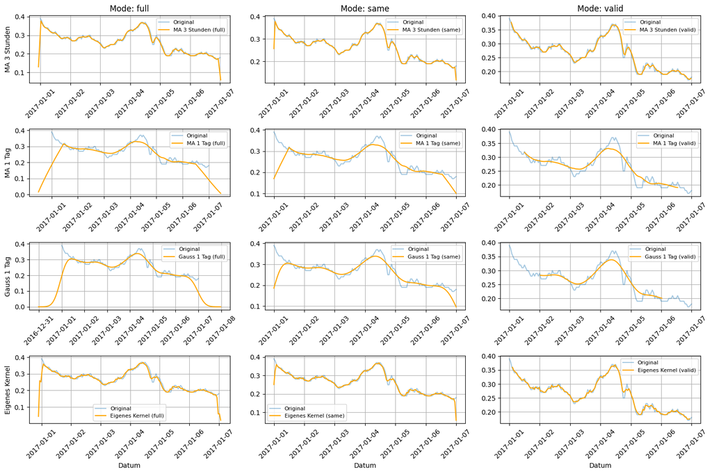

```python
from scipy.signal.windows import gaussian

# --- Auswahl Zeitraum: eine Woche Anfang 2017 ---
start_date = pd.Timestamp("2017-01-01")
end_date   = pd.Timestamp("2017-01-07")
mask_week = (dates >= start_date) & (dates <= end_date)
x_week = x[mask_week]
dates_week = dates[mask_week]

# --- Verschiedene Kernel definieren ---
window_3h = 3
window_24h  = 24

kernel_ma_3h = np.ones(window_3h) / window_3h
kernel_ma_24h = np.ones(window_24h) / window_24h
kernel_gauss = gaussian(window_24h*2+1, std=6)
kernel_gauss /= np.sum(kernel_gauss)
kernel_self = np.array([0.1, 0.5, 0, 0.2, 0.1])
kernel_self /= np.sum(kernel_self)

kernels = {
    "MA 3 Stunden": kernel_ma_3h,
    "MA 1 Tag": kernel_ma_24h,
    "Gauss 1 Tag": kernel_gauss,
    "Eigenes Kernel": kernel_self
}

modes = ['full', 'same', 'valid']

# --- Convolution testen ---
plt.figure(figsize=(15,10))

for i, (kname, k) in enumerate(kernels.items(), start=1):
    for j, mode in enumerate(modes, start=1):
        # Convolution
        y_conv, pad_left = manual_convolution(x_week, k, mode=mode)

        # x-Achse anpassen
        if mode == 'full':
            # Bei full: Output startet M-1 Zeitschritte VOR dem ersten Signal-Punkt
            shift = 0.5*len(k)
            dates_plot = pd.date_range(
                start=dates_week[0] - pd.Timedelta(hours=shift),
                periods=len(y_conv),
                freq='h'
            )
        elif mode == 'same':
            dates_plot = dates_week
        elif mode == 'valid':
            # Bei valid: Output startet M-1 Zeitschritte NACH dem ersten Signal-Punkt
            shift = 0.5*len(k)
            dates_plot = pd.date_range(
                start=dates_week[0] + pd.Timedelta(hours=shift),
                periods=len(y_conv),
                freq='h'
            )

        # Subplot
        plt.subplot(len(kernels), len(modes), (i-1)*len(modes)+j)
        plt.plot(dates_week, x_week, label='Original', alpha=0.4)
        plt.plot(dates_plot, y_conv, label=f'{kname} ({mode})', color='orange')
        plt.xticks(rotation=45)

        if i == 1:
            plt.title(f'Mode: {mode}')
        if j == 1:
            plt.ylabel(kname)
        if i == len(kernels):
            plt.xlabel('Datum')
        plt.grid(True)
        plt.legend(fontsize=8)

plt.tight_layout()
plt.show()
```

Man sieht im Plot, dass die Convolution mit dem manuellen Verfahren funktioniert, man kann sowohl ein Moving Average, einen Gaussfilter oder einen selbst erstellten Filter verwenden. Im Anschluss soll die Funktion mit der Numpy-Funktion `np.convolve` verglichen werden.

```
VERGLEICH: Manuelle Convolution vs NumPy

MA 3h (full):
  Max Abs Error:   0.00e+00
  Mean Abs Error:  0.00e+00
  RMSE:            0.00e+00
  Rel. Error:      0.0000%
  Identisch:       JA

MA 3h (same):
  Max Abs Error:   0.00e+00
  Mean Abs Error:  0.00e+00
  RMSE:            0.00e+00
  Rel. Error:      0.0000%
  Identisch:       JA

MA 3h (valid):
  Max Abs Error:   0.00e+00
  Mean Abs Error:  0.00e+00
  RMSE:            0.00e+00
  Rel. Error:      0.0000%
  Identisch:       JA

MA 24h (full):
  Max Abs Error:   5.55e-17
  Mean Abs Error:  1.34e-17
  RMSE:            2.61e-17
  Rel. Error:      0.0000%
  Identisch:       JA

MA 24h (same):
  Max Abs Error:   5.55e-17
  Mean Abs Error:  1.55e-17
  RMSE:            2.81e-17
  Rel. Error:      0.0000%
  Identisch:       JA

MA 24h (valid):
  Max Abs Error:   5.55e-17
  Mean Abs Error:  1.80e-17
```

[output cut: 30 more lines]

```
  Identisch:       JA

Custom (same):
  Max Abs Error:   0.00e+00
  Mean Abs Error:  0.00e+00
  RMSE:            0.00e+00
  Rel. Error:      0.0000%
  Identisch:       JA

Custom (valid):
  Max Abs Error:   0.00e+00
  Mean Abs Error:  0.00e+00
  RMSE:            0.00e+00
  Rel. Error:      0.0000%
  Identisch:       JA
```

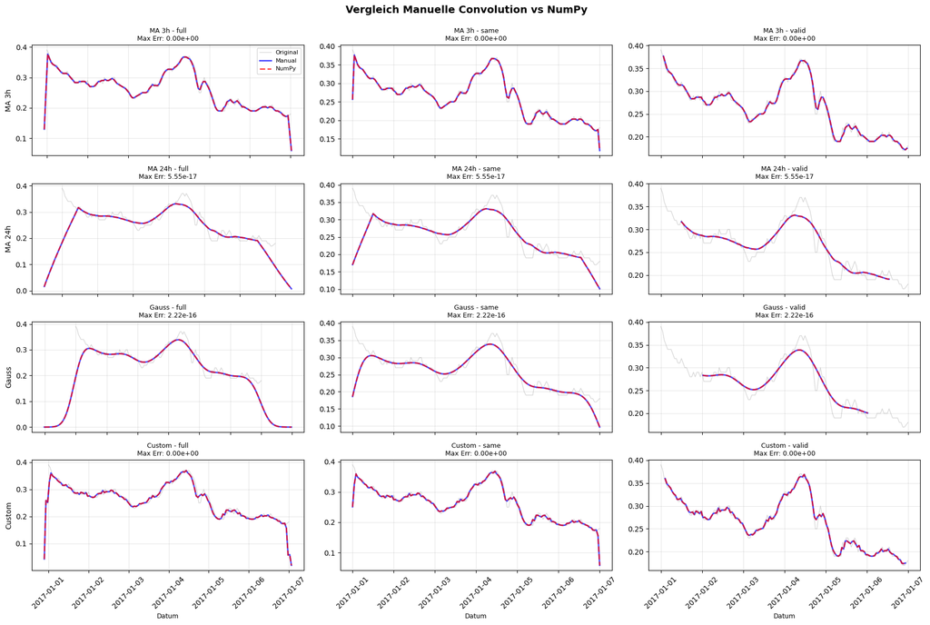

```python
import time

def compare_convolutions(signal, kernel, mode='same'):
    """
    Vergleicht manuelle Convolution mit NumPy's convolve.
    Gibt Ergebnisse, Zeitdauer und Fehlermetriken zurück.
    """
    # Manuelle Convolution
    start_manual = time.perf_counter()
    y_manual, _ = manual_convolution(signal, kernel, mode=mode)
    time_manual = time.perf_counter() - start_manual

    # NumPy Convolution
    start_numpy = time.perf_counter()
    y_numpy = np.convolve(signal, kernel, mode=mode)
    time_numpy = time.perf_counter() - start_numpy

    # Fehlermetriken berechnen
    max_abs_error = np.max(np.abs(y_manual - y_numpy))
    mean_abs_error = np.mean(np.abs(y_manual - y_numpy))
    rmse = np.sqrt(np.mean((y_manual - y_numpy)**2))
    relative_error = np.max(np.abs(y_manual - y_numpy) / (np.abs(y_numpy) + 1e-10)) * 100

    results = {
        'manual': y_manual,
        'numpy': y_numpy,
        'time_manual': time_manual * 1000,  # in ms
        'time_numpy': time_numpy * 1000,     # in ms
        'speedup': time_manual / time_numpy,
        'max_abs_error': max_abs_error,
        'mean_abs_error': mean_abs_error,
        'rmse': rmse,
        'relative_error': relative_error,
        'identical': np.allclose(y_manual, y_numpy, rtol=1e-9, atol=1e-12)
    }

    return results


# Eine Woche stündliche Daten
start_date = pd.Timestamp("2017-01-01")
end_date   = pd.Timestamp("2017-01-07")
mask_week = (dates >= start_date) & (dates <= end_date)
x_week = x[mask_week]
dates_week = dates[mask_week]

# --- Kernel definieren ---
window_3h = 3
window_24h = 24

kernel_ma_3h = np.ones(window_3h) / window_3h
kernel_ma_24h = np.ones(window_24h) / window_24h
kernel_gauss = gaussian(window_24h*2+1, std=6)
kernel_gauss /= np.sum(kernel_gauss)
kernel_self = np.array([0.1, 0.5, 0, 0.2, 0.1])
kernel_self /= np.sum(kernel_self)

kernels = {
    "MA 3h": kernel_ma_3h,
    "MA 24h": kernel_ma_24h,
    "Gauss": kernel_gauss,
    "Custom": kernel_self
}

modes = ['full', 'same', 'valid']

# --- Vergleich durchführen ---
print("VERGLEICH: Manuelle Convolution vs NumPy")

all_results = {}

for kname, k in kernels.items():
    for mode in modes:
        key = f"{kname} ({mode})"
        results = compare_convolutions(x_week, k, mode=mode)
        all_results[key] = results

        print(f"\n{key}:")
        print(f"  Max Abs Error:   {results['max_abs_error']:.2e}")
        print(f"  Mean Abs Error:  {results['mean_abs_error']:.2e}")
        print(f"  RMSE:            {results['rmse']:.2e}")
        print(f"  Rel. Error:      {results['relative_error']:.4f}%")
        print(f"  Identisch:       {'JA' if results['identical'] else 'NEIN'}")

# --- Visualisierung ---
fig = plt.figure(figsize=(18, 12))
fig.suptitle('Vergleich Manuelle Convolution vs NumPy', fontsize=14, fontweight='bold', y=0.995)

# Plot 1: Visueller Vergleich für alle Kombinationen
for i, (kname, k) in enumerate(kernels.items(), start=1):
    for j, mode in enumerate(modes, start=1):
        key = f"{kname} ({mode})"
        results = all_results[key]

        ax = plt.subplot(len(kernels), len(modes), (i-1)*len(modes)+j)

        # Originalsignal
        ax.plot(dates_week, x_week, label='Original', alpha=0.3, color='gray', linewidth=1)

        # Beide Convolutions
        if mode == 'full':
            shift = 0.5*len(k)
            dates_plot = pd.date_range(start=dates_week[0] - pd.Timedelta(hours=shift),
                                      periods=len(results['manual']), freq='h')
        elif mode == 'same':
            dates_plot = dates_week
        else:  # valid
            shift = 0.5*len(k)
            dates_plot = pd.date_range(start=dates_week[0] + pd.Timedelta(hours=shift),
                                      periods=len(results['manual']), freq='h')

        ax.plot(dates_plot, results['manual'], label='Manual', color='blue', linewidth=2, alpha=0.7)
        ax.plot(dates_plot, results['numpy'], label='NumPy', color='red', linewidth=2,
                linestyle='--', alpha=0.7)

        # Fehler im Titel
        ax.set_title(f'{kname} - {mode}\nMax Err: {results["max_abs_error"]:.2e}', fontsize=9)

        if j == 1:
            ax.set_ylabel(kname, fontsize=10)
        if i == len(kernels):
            ax.set_xlabel('Datum', fontsize=9)
            ax.tick_params(axis='x', rotation=45)
        else:
            ax.set_xticklabels([])

        ax.grid(True, alpha=0.3)
        if i == 1 and j == 1:
            ax.legend(fontsize=8, loc='upper right')

plt.tight_layout()
plt.savefig('convolution_comparison_visual.png', dpi=150, bbox_inches='tight')
plt.show()
```

Im Vergleich zur Numpy-Funktion `np.convolve` ist die manuelle Implementierung gleich, es gibt keine Abweichungen. Jedoch ist die Numpy-Funktion wahrscheinlich deutlich schneller in der Berechnung und hat ein besseres Errror-Handling.

## Day 11

### Use Case

Um zu sehen, ob der Klimawandel einen Einfluss auf den Wasserstand des St.-Lawrence-Stroms hat, soll ein Trend über die Jahre berechnet werden. Hierzu wird das Signal mit einem gleitenden Mittelwert über 12 Monate geglättet. So werden die Saisonalitäten wie die Schneeschmelze entfernt und ein langfristiger Trend wird sichtbar. Falls es einen Trend gibt, könnte dies auf den Klimawandel hindeuten un man müsste weitere Untersuchungen anstellen um die Infrastruktur der Zukunft den neuen Gegebenheiten anzupassen.

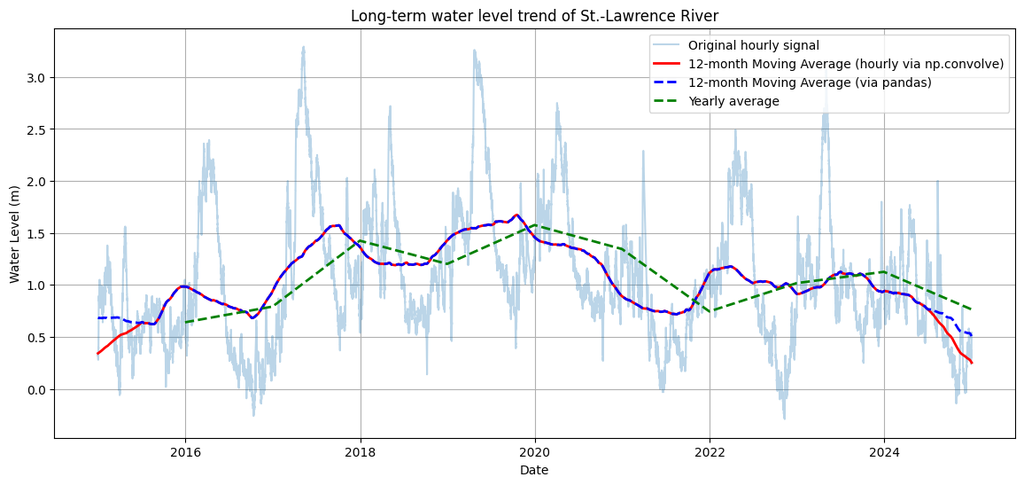

```python
# Signal vorbereiten (jährliche Mittelwerte aus täglichen Messungen)
sig = water_raw.set_index('Observed_date')['Sealevel'].asfreq('h').interpolate(limit=16*24)
dates = sig.index
x = sig.values

# 2. 12-Monats-Gleitender Mittelwert in Stunden umrechnen
# 12 Monate ≈ 365 Tage -> 365*24 Stunden
window_hours = 365 * 24
kernel = np.ones(window_hours) / window_hours

# 3. Convolution
x_trend = np.convolve(x, kernel, mode='same')

# 4. Pandas Rolling Mean (als Vergleich)
x_trend_pd = sig.rolling(window='365D', center=True).mean()

# 4. Vergleich: Jährlicher Mittelwert
yearly_avg = sig.resample('YE').mean()

# 5. Visualisierung
plt.figure(figsize=(14,6))
plt.plot(dates, x, alpha=0.3, label='Original hourly signal')
plt.plot(dates, x_trend, color='red', label='12-month Moving Average (hourly via np.convolve)', linewidth=2)
plt.plot(x_trend_pd.index, x_trend_pd.values, '--', color='blue', label='12-month Moving Average (via pandas)', linewidth=2)
plt.plot(yearly_avg.index, yearly_avg.values, '--', color='green', label='Yearly average', linewidth=2)
plt.title('Long-term water level trend of St.-Lawrence River')
plt.xlabel('Date'); plt.ylabel('Water Level (m)')
plt.grid()
plt.legend()
plt.show()
```

Man sieht im Plot keine klare Tendenz. Was aber im Bezug auf das Filtering auffällt, ist dass die saisonalen Schwankungen deutlich reduziert wurden. Im Vergleich sieht man noch das Jährliche Mittel abgebildet durch die grüne Linie. Diese Linie ist aber nicht so aussagekräftig wie die geglättete Kurve obwohl man sehen kann, dass diese ähnlich verläuft.

Von hier an bis zu Tag 12 ist alles neu.

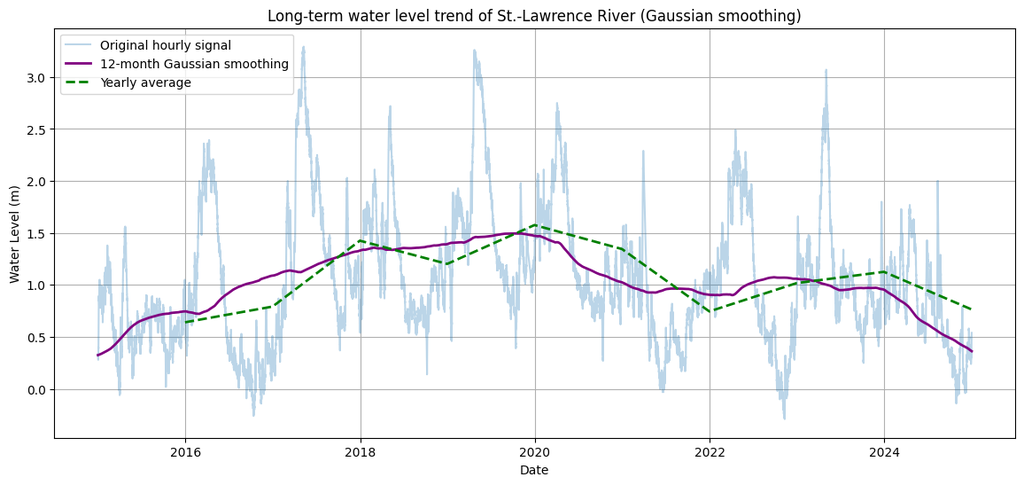

```python
# --- Gaussfilter über 12 Monate ---
std_months = 12
std_hours = std_months * 30.42 * 24  # ~ durchschnittliche Stunden in 12 Monaten
window_hours_gauss = int(2 * std_hours + 1)  # 12 Monate -> Fensterbreite
kernel_gauss = gaussian(window_hours_gauss, std=std_hours)
kernel_gauss /= np.sum(kernel_gauss)
x_trend_gauss = np.convolve(x, kernel_gauss, mode='same')

# --- Convolution mit Gaussfilter ---
x_trend_gauss = np.convolve(x, kernel_gauss, mode='same')

# --- Jährlicher Mittelwert zum Vergleich ---
yearly_avg = sig.resample('YE').mean()

# --- Plot ---
plt.figure(figsize=(14,6))
plt.plot(dates, x, alpha=0.3, label='Original hourly signal')
plt.plot(dates, x_trend_gauss, color='purple', label='12-month Gaussian smoothing', linewidth=2)
plt.plot(yearly_avg.index, yearly_avg.values, '--', color='green', label='Yearly average', linewidth=2)

plt.title('Long-term water level trend of St.-Lawrence River (Gaussian smoothing)')
plt.xlabel('Date')
plt.ylabel('Water Level (m)')
plt.grid(True)
plt.legend()
plt.show()
```

Beim Gaussfilter werden die saisonalen Schwankungen noch stärker geglättet als beim Moving Average. Dies soll nun noch mit dem Moving Average verglichen werden.

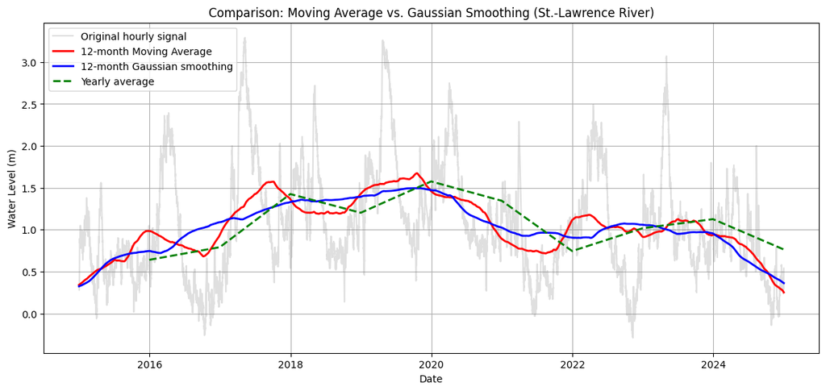

```
Vergleich Moving Average vs. Gaussian Smoothing
RMSE zwischen MA und Gauss: 0.143157 m
Mittlere absolute Abweichung (MAE): 0.120069 m

Varianz Originalsignal: 0.424831
Varianz nach 12-Monats-MA: 0.101538  → Reduktion: 76.10%
Varianz nach 12-Monats-Gauss: 0.083311  → Reduktion: 80.39%
```

```python
# --- Signal vorbereiten ---
sig = water_raw.set_index('Observed_date')['Sealevel'].asfreq('h').interpolate(limit=16*24)
dates = sig.index
x = sig.values

# --- Moving Average über 12 Monate (≈ 1 Jahr) ---
window_hours_ma = 365 * 24
kernel_ma = np.ones(window_hours_ma) / window_hours_ma
x_trend_ma = np.convolve(x, kernel_ma, mode='same')

# --- Gaussfilter über 12 Monate ---
std_months = 12
std_hours = std_months * 30.42 * 24  # ~ durchschnittliche Stunden in 12 Monaten
window_hours_gauss = int(2 * std_hours + 1)  # 12 Monate -> Fensterbreite
kernel_gauss = gaussian(window_hours_gauss, std=std_hours)
kernel_gauss /= np.sum(kernel_gauss)
x_trend_gauss = np.convolve(x, kernel_gauss, mode='same')

# --- Jahresmittelwerte zum Vergleich ---
yearly_avg = sig.resample('YE').mean()

# --- Plot ---
plt.figure(figsize=(14,6))
plt.plot(dates, x, alpha=0.25, color='gray', label='Original hourly signal')
plt.plot(dates, x_trend_ma, color='red', label='12-month Moving Average', linewidth=2)
plt.plot(dates, x_trend_gauss, color='blue', label='12-month Gaussian smoothing', linewidth=2)
plt.plot(yearly_avg.index, yearly_avg.values, '--', color='green', label='Yearly average', linewidth=2)

plt.title('Comparison: Moving Average vs. Gaussian Smoothing (St.-Lawrence River)')
plt.xlabel('Date')
plt.ylabel('Water Level (m)')
plt.legend()
plt.grid(True)
plt.show()

# --- Quantitative Analyse ---
diff = x_trend_ma - x_trend_gauss

rmse = np.sqrt(np.mean(diff**2))
mae = np.mean(np.abs(diff))

# Varianzreduktion
var_original = np.var(x)
var_ma = np.var(x_trend_ma)
var_gauss = np.var(x_trend_gauss)
reduction_ma = 100 * (1 - var_ma / var_original)
reduction_gauss = 100 * (1 - var_gauss / var_original)

# --- Ergebnisse ---
print("Vergleich Moving Average vs. Gaussian Smoothing")
print(f"RMSE zwischen MA und Gauss: {rmse:.6f} m")
print(f"Mittlere absolute Abweichung (MAE): {mae:.6f} m")
print()
print(f"Varianz Originalsignal: {var_original:.6f}")
print(f"Varianz nach 12-Monats-MA: {var_ma:.6f}  → Reduktion: {reduction_ma:.2f}%")
print(f"Varianz nach 12-Monats-Gauss: {var_gauss:.6f}  → Reduktion: {reduction_gauss:.2f}%")
```

## Day 12

Um die Daten aus der Konvolution wieder zurückzutransformieren, wird eine Dekonvolution durchgeführt. Ziel ist es mit einer Wiener-Dekonvolution das ursprüngliche Signal wiederherzustellen. Hierzu wird die geglättete Kurve (12-Monats-Moving Average) verwendet und mit dem gleichen Kernel wie bei der Faltung gefiltert. Dadurch soll das ursprüngliche Signal wiederhergestellt werden.

Von hier an bis zu Tag 13 ist alles angepasst, neue Hyperparameter und Shift hinzugefügt.

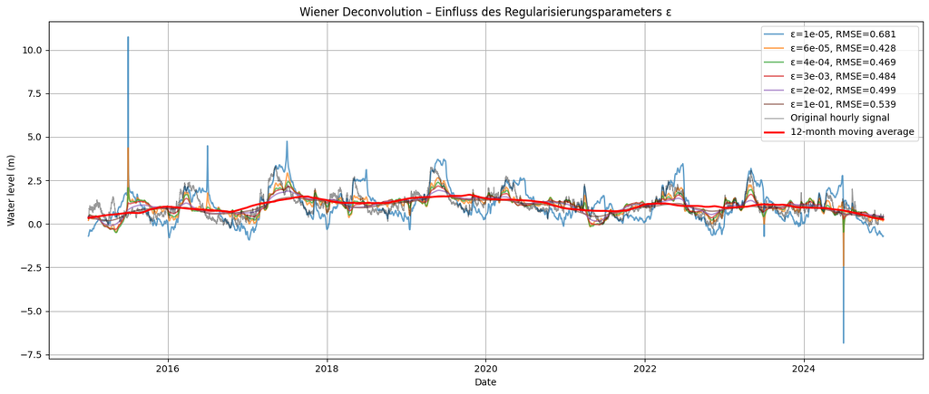

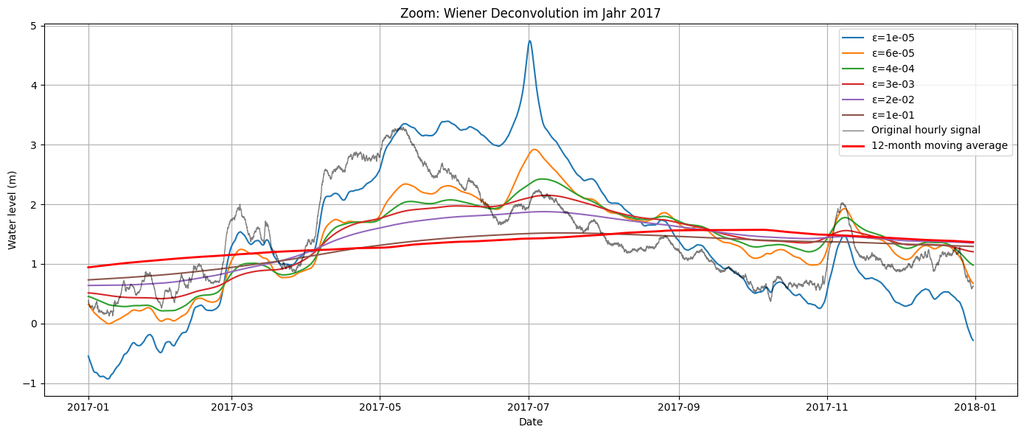

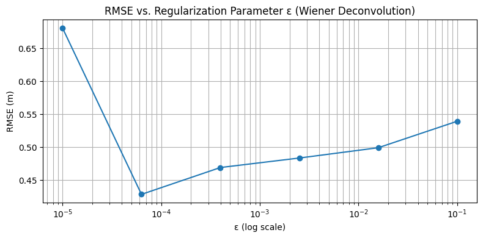

```
Beste Regularisierung: ε = 6.310e-05, minimaler RMSE = 0.428 m
```

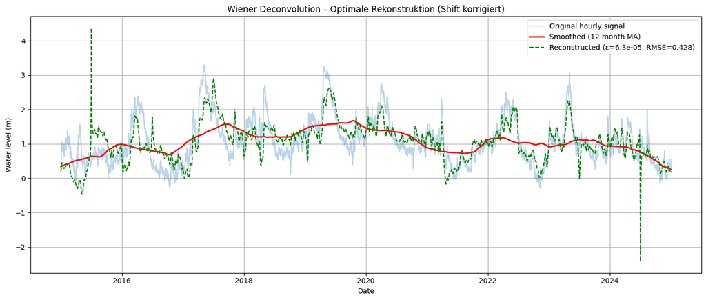

```python
# --- 1. Originalsignal vorbereiten ---
sig = water_raw.set_index('Observed_date')['Sealevel'].asfreq('h').interpolate(limit=16*24)
x = sig.values
dates = sig.index

# --- 2. Glättungskernel: 12 Monate gleitender Mittelwert ---
window_hours = 365 * 24
kernel = np.ones(window_hours) / window_hours

# --- 3. Trendbildung (Faltung) ---
x_trend = np.convolve(x, kernel, mode='same')

# --- 4. FFTs vorbereiten ---
kernel_fft = np.fft.fft(kernel, n=len(x))
x_trend_fft = np.fft.fft(x_trend)

# --- 5. Parameterstudie: verschiedene epsilon-Werte ---
eps_values = np.logspace(-5, -1, 6)  # z. B. [1e-5, 1e-4, ..., 1e-1]
rmse_list = []

# Berechnung des Shifts: halbe Kernel-Länge
shift = 6 * 24 * 30.42

plt.figure(figsize=(14, 6))

for eps in eps_values:
    # --- Wiener-Dekonvolution ---
    x_reconstructed = np.fft.ifft(
        x_trend_fft * np.conj(kernel_fft) / (kernel_fft * np.conj(kernel_fft) + eps)
    ).real

    # --- Shift-Korrektur anwenden ---
    x_reconstructed = np.roll(x_reconstructed, shift)

    # --- RMSE-Berechnung ---
    rmse = np.sqrt(np.mean((x - x_reconstructed) ** 2))
    rmse_list.append(rmse)

    # --- Plot rekonstruierter Signale ---
    plt.plot(dates, x_reconstructed, label=f'ε={eps:.0e}, RMSE={rmse:.3f}', alpha=0.7)

# --- Original- und geglättetes Signal ---
plt.plot(dates, x, color='black', linewidth=1, alpha=0.4, label='Original hourly signal')
plt.plot(dates, x_trend, color='red', linewidth=2, label='12-month moving average')

plt.title('Wiener Deconvolution – Einfluss des Regularisierungsparameters ε')
plt.xlabel('Date')
plt.ylabel('Water level (m)')
plt.legend()
plt.grid()
plt.tight_layout()
plt.show()

# --- 6. Zoom-Ansicht für 2017 ---
start_zoom = '2017-01-01'
end_zoom = '2017-12-31'

zoom_mask = (dates >= start_zoom) & (dates <= end_zoom)
dates_zoom = dates[zoom_mask]
x_zoom = x[zoom_mask]
x_trend_zoom = x_trend[zoom_mask]

plt.figure(figsize=(14, 6))

for eps in eps_values:
    x_reconstructed = np.fft.ifft(
        x_trend_fft * np.conj(kernel_fft) / (kernel_fft * np.conj(kernel_fft) + eps)
    ).real
    x_reconstructed = np.roll(x_reconstructed, shift)
    x_reconstructed_zoom = x_reconstructed[zoom_mask]
    plt.plot(dates_zoom, x_reconstructed_zoom, label=f'ε={eps:.0e}')

plt.plot(dates_zoom, x_zoom, color='black', linewidth=1, alpha=0.5, label='Original hourly signal')
plt.plot(dates_zoom, x_trend_zoom, color='red', linewidth=2, label='12-month moving average')

plt.title('Zoom: Wiener Deconvolution im Jahr 2017')
plt.xlabel('Date')
plt.ylabel('Water level (m)')
plt.legend()
plt.grid()
plt.tight_layout()
plt.show()


# --- RMSE-Diagramm ---
plt.figure(figsize=(8, 4))
plt.semilogx(eps_values, rmse_list, marker='o')
plt.title('RMSE vs. Regularization Parameter ε (Wiener Deconvolution)')
plt.xlabel('ε (log scale)')
plt.ylabel('RMSE (m)')
plt.grid(True, which='both')
plt.tight_layout()
plt.show()

# --- Beste Lösung identifizieren ---
best_eps = eps_values[np.argmin(rmse_list)]
print(f"Beste Regularisierung: ε = {best_eps:.3e}, minimaler RMSE = {min(rmse_list):.3f} m")

# --- Finaler Plot der besten Rekonstruktion ---
x_reconstructed_best = np.fft.ifft(
    x_trend_fft * np.conj(kernel_fft) / (kernel_fft * np.conj(kernel_fft) + best_eps)
).real
x_reconstructed_best = np.roll(x_reconstructed_best, shift)

plt.figure(figsize=(14, 6))
plt.plot(dates, x, alpha=0.3, label='Original hourly signal')
plt.plot(dates, x_trend, color='red', linewidth=2, label='Smoothed (12-month MA)')
plt.plot(dates, x_reconstructed_best, color='green', linestyle='--',
         label=f'Reconstructed (ε={best_eps:.1e}, RMSE={min(rmse_list):.3f})')
plt.title('Wiener Deconvolution – Optimale Rekonstruktion (Shift korrigiert)')
plt.xlabel('Date')
plt.ylabel('Water level (m)')
plt.legend()
plt.grid()
plt.tight_layout()
plt.show()
```

In einem nächsten Schritt wird noch versuch das Signal mithilfe einer Tikhonov-Regularisierung zu rekonstruieren. Der Unterschied zur Wiener-Dekonvolution ist, dass hier ein Regularisierungsterm hinzugefügt wird, der die Lösung glättet und somit das Rauschen reduziert.

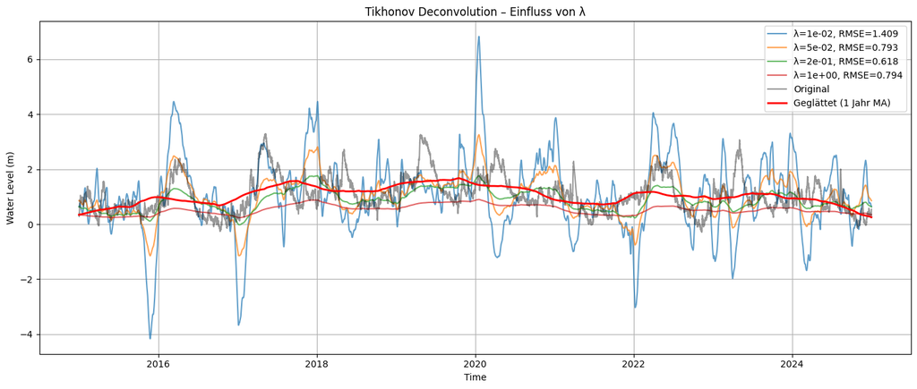

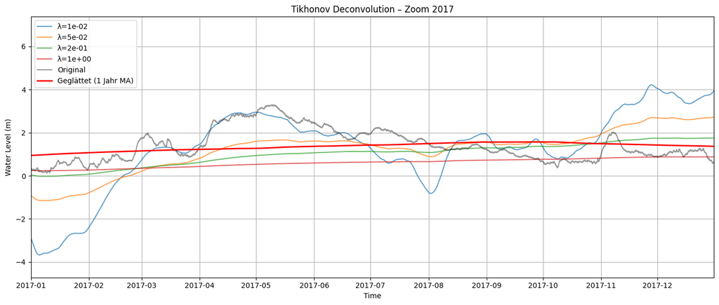

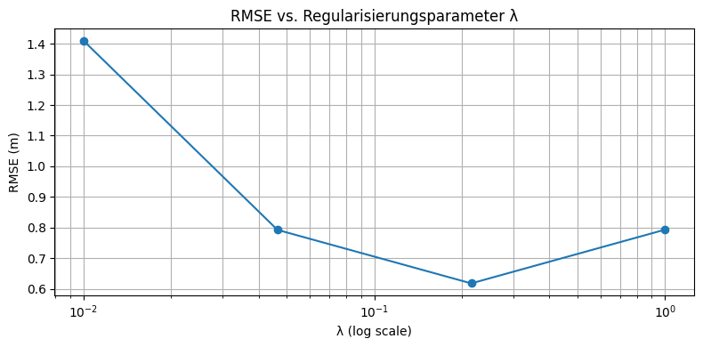

```
Beste λ: 2.154e-01, minimaler RMSE: 0.618 m
```

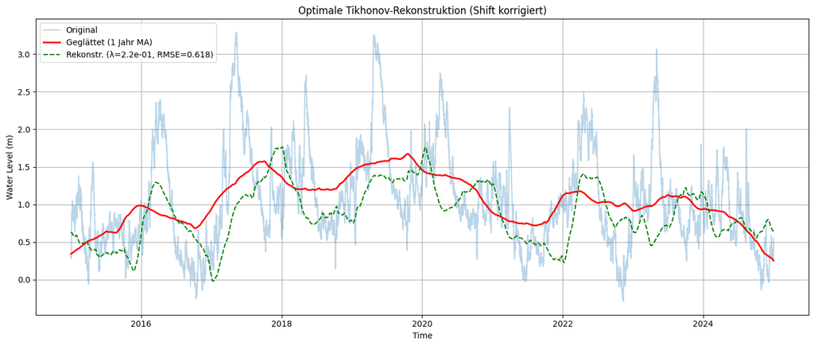

```python
# --- Daten vorbereiten ---
sig = water_raw.set_index('Observed_date')['Sealevel'].asfreq('h').interpolate(limit=24*16)
x_orig = sig.values.astype(float)
t_index = sig.index

# --- Glättungskernel (z.B. 1 Jahr Mittelwert) ---
kernel_size = 365 * 24  # 1 Jahr in Stunden
kernel = np.ones(kernel_size) / kernel_size

# --- Faltung für geglättetes Signal ---
x_smooth = np.convolve(x_orig, kernel, mode='same')

# --- FFTs vorbereiten ---
X = np.fft.fft(x_orig)
K = np.fft.fft(kernel, n=len(X))

# --- Parameterstudie ---
lambda_values = np.logspace(-2, 0, 4)
rmse_list = []

# --- Shift: halbe Kernel-Länge ---
shift = 9 * 24 * 30.42

plt.figure(figsize=(14,6))

for lam in lambda_values:
    # --- Tikhonov-Deconvolution ---
    X_deconv = np.conj(K) / (np.abs(K)**2 + lam) * X
    x_recon = np.fft.ifft(X_deconv).real

    # --- Shift anwenden ---
    x_recon = np.roll(x_recon, shift)

    # --- RMSE berechnen ---
    rmse = np.sqrt(np.mean((x_orig - x_recon)**2))
    rmse_list.append(rmse)

    # --- Plot rekonstruierter Signale ---
    plt.plot(t_index, x_recon, label=f'λ={lam:.0e}, RMSE={rmse:.3f}', alpha=0.7)

# --- Original und geglättet ---
plt.plot(t_index, x_orig, color='black', alpha=0.4, label='Original')
plt.plot(t_index, x_smooth, color='red', linewidth=2, label='Geglättet (1 Jahr MA)')

plt.xlabel('Time')
plt.ylabel('Water Level (m)')
plt.title('Tikhonov Deconvolution – Einfluss von λ')
plt.legend()
plt.grid()
plt.tight_layout()
plt.show()

# --- Zoom auf 2017 ---
start_zoom = pd.Timestamp("2017-01-01")
end_zoom = pd.Timestamp("2017-12-31")
plt.figure(figsize=(14,6))
for lam in lambda_values:
    # Tikhonov-Deconvolution nochmal berechnen (oder aus vorheriger Schleife speichern)
    X_deconv = np.conj(K) / (np.abs(K)**2 + lam) * X
    x_recon = np.fft.ifft(X_deconv).real
    x_recon = np.roll(x_recon, shift)

    plt.plot(t_index, x_recon, label=f'λ={lam:.0e}', alpha=0.7)

# Original und geglättet
plt.plot(t_index, x_orig, color='black', alpha=0.4, label='Original')
plt.plot(t_index, x_smooth, color='red', linewidth=2, label='Geglättet (1 Jahr MA)')

plt.xlabel('Time')
plt.ylabel('Water Level (m)')
plt.title('Tikhonov Deconvolution – Zoom 2017')
plt.legend()
plt.grid()
plt.xlim(start_zoom, end_zoom)  # <-- hier wird der Zoom gesetzt
plt.tight_layout()
plt.show()

# --- RMSE vs Lambda ---
plt.figure(figsize=(8,4))
plt.semilogx(lambda_values, rmse_list, marker='o')
plt.xlabel('λ (log scale)')
plt.ylabel('RMSE (m)')
plt.title('RMSE vs. Regularisierungsparameter λ')
plt.grid(True, which='both')
plt.tight_layout()
plt.show()

# --- Beste lambda auswählen ---
best_lambda = lambda_values[np.argmin(rmse_list)]
print(f"Beste λ: {best_lambda:.3e}, minimaler RMSE: {min(rmse_list):.3f} m")

# --- Final: beste Rekonstruktion ---
X_best = np.conj(K) / (np.abs(K)**2 + best_lambda) * X
x_best = np.fft.ifft(X_best).real
x_best = np.roll(x_best, shift)

plt.figure(figsize=(14,6))
plt.plot(t_index, x_orig, alpha=0.3, label='Original')
plt.plot(t_index, x_smooth, color='red', linewidth=2, label='Geglättet (1 Jahr MA)')
plt.plot(t_index, x_best, color='green', linestyle='--',
         label=f'Rekonstr. (λ={best_lambda:.1e}, RMSE={min(rmse_list):.3f})')
plt.xlabel('Time')
plt.ylabel('Water Level (m)')
plt.title('Optimale Tikhonov-Rekonstruktion (Shift korrigiert)')
plt.legend()
plt.grid()
plt.tight_layout()
plt.show()
```

Auch die Tikhonov-Regularisierung liefert eine gute Rekonstruktion des Signals. Jedoch nicht so gut wie die Wiener-Dekonvolution. Auffällig ist auch der deutlich grössere Parameter und der höhere RMSE-Wert von 0.618.

## Day 13

### Use Case und Relevanz

Für meinen Anwendungsfall, die Analyse langfristiger Trends im Wasserstand des St.-Lawrence-Stroms, ist die Dekonvolution aktuell nicht zwingend notwendig, da die Daten bereits stündlich vorliegen. Die Analyse könnte direkt auf den Originaldaten erfolgen. Dennoch bietet die Dekonvolution in anderen Szenarien einen Mehrwert: Wenn nur aggregierte oder verrauschte Daten, z. B. monatliche Mittelwerte, vorliegen, kann die Dekonvolution helfen, die zeitliche Auflösung zu erhöhen und Rauschen zu reduzieren, sodass eine glattere Rekonstruktion stündlicher Werte möglich wird.

## Day 14

Durch die Konvolution hat man gesehen, dass im angeschauten Zeitraum keine langfristigen Trends im Wasserstand des St.-Lawrence-Stroms zu erkennen sind. Es wäre vielleicht aber sinnvoll, die Daten über einen längeren Zeitraum zu analysieren, um mögliche Trends zu erkennen. Trotzdem kann man durch eine Glättung die saisonalen Schwankungen reduzieren und so den langfristigen Trend besser erkennen.

Die Rekonstuktion des Signals durch die Dekonvolution war erfolgreich. Mithilfe von Parametertuning und dem Shift konnte ich im nachgang meine Dekonvolution so verändern, dass sie die Daten relativ gut nachempfinden konnte. Anwendungsmässig, macht eine Dekonvolution in diesem Fall wenig Sinn, da die Daten bereits stündlich vorliegen und eine Rekonstruktion auf den aktuellen Daten nur wenig sinnvoll ist.

## Day 15

### Reflektion

Ich habe während dieser Minichallenge einiges über 1D-Signale gelernt. Angefangen damit, dass für mich Signale immer nur Audiosignale waren und ich schnell gesehen habe, dass es viele andere Anwendungsfälle gibt. Gerade die Visualisierungen der Signale und der einzelnen Analysen fand ich gelungen. Sie haben mir oft geholfen, das Ergebniss und auch die angewendeten Methoden besser zu verstehen.

Ausbaufähig wäre wahrscheinlich noch der Mathematische Hintergrund zu den einzelnen Methoden. Hier habe ich zwar die Grundidee verstanden, aber ich denke, dass ich hier noch mehr lernen könnte. Auch bei der Dekonvolution hatte ich wahrscheinlich nicht die besten Daten und konnte daher nicht das beste Ergebniss erzielen.

Am Lernreichsten fand ich das Niquist-Shannon Sampling Theorem. Gerade hier konnte ich durch die Visualisierungen sehr gut verstehen, warum dieses Theorem so wichtig ist und auch, dass es nicht immer eine perfekte Rekonstruktion gibt. Beipielsweise habe ich erkannt, das eine Saisonalität in der Theorie nur alle 6 Monate gemessen werden muss aber in der Praxis macht es Sinn, dies häufiger zu tun um eine bessere Rekonstruktion zu erhalten.